# Exploration of the GoBike dataset

## by Konstantin Leonenko

## Investigation Overview

In this investigation I wanted to see how the load is spread across the bike sharing network.

## Dataset Overview

Dataset represents almost three years (2017-2019) of records of bike trips across the GoBike network deployed in the SanFrancisco bay area. Information included bike id, start and end station locations and times as well as rider's gender, age and client type.

## Ride Duration

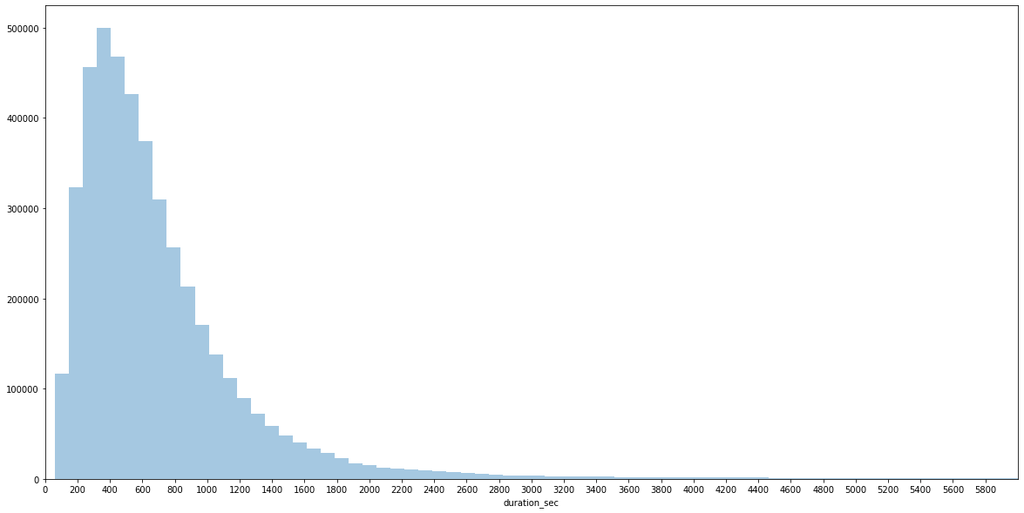

```python
plt.figure(figsize=(20,10))
sb.distplot(df_rides.duration_sec,1000,kde=False);
plt.xlim(0,6000);
plt.xticks(np.arange(0,6000,200));
```

## Station start/end balance

From the overall grey color of the plot - it looks like on average the start and end stations popularity is mostly well balanced, however colored bar tips tell us that some stations have more starts and some - more ends.

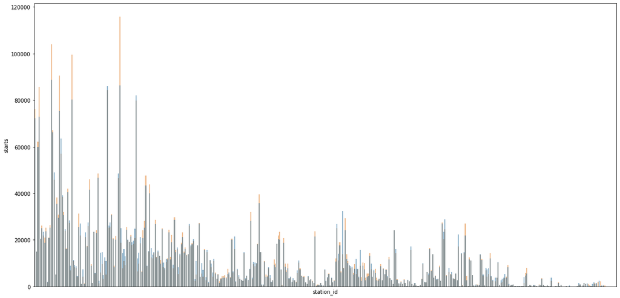

```python
plt.figure(figsize=(20,10))
sb.barplot(data=df_stations_clean, x='station_id', y='ends', color = secondary_color, alpha=0.5);
sb.barplot(data=df_stations_clean, x='station_id', y='starts', color = base_color, alpha=0.5);
# sb.barplot(data=df_stations_clean, x='station_id', y='starts')
plt.xticks([]);
```

## Start/Stop station scatter plot

In this scatter plot every dot is placed to represent start and end station. From this visualization it is clear that:

- Travel patterns are clustered around very specific groups of stations.
- Roundtrips, where start and end stations are the same are quite popular.
- Plot is very symmetrical along the diagonal, which means a lot of bikes go back to the same stations they were picked up from

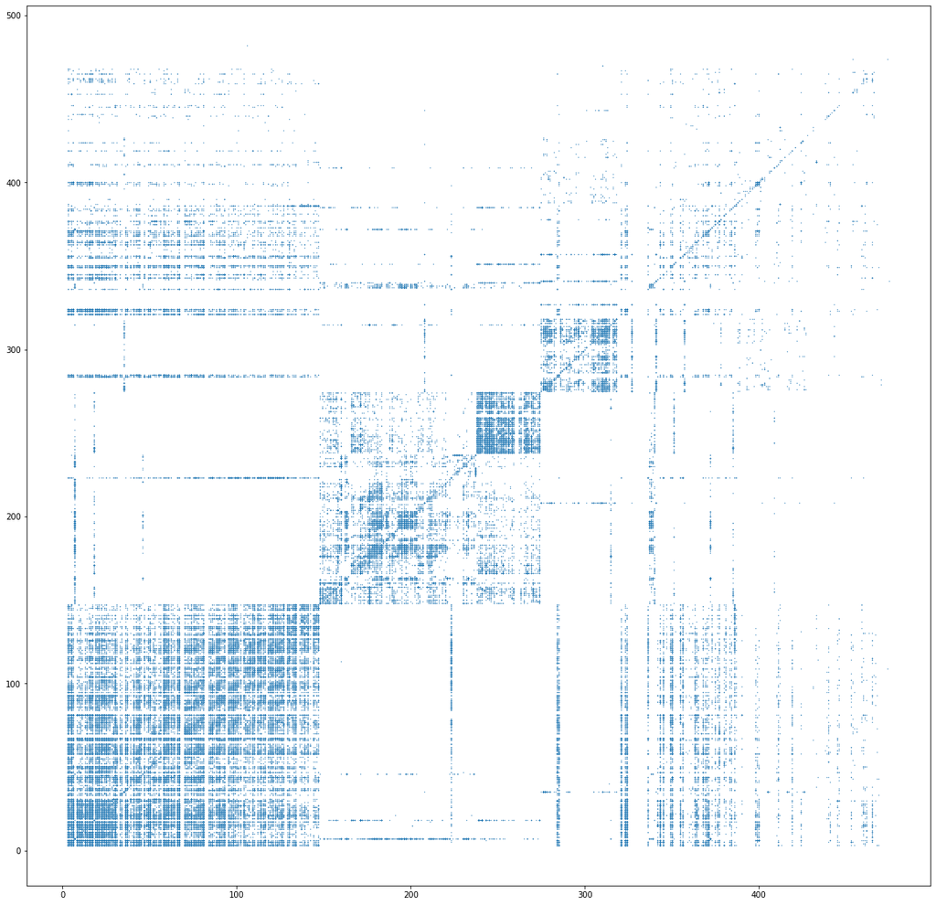

```python
sample = np.random.choice(df_rides.shape[0],200000, replace = False);
sample = df_rides.loc[sample];
plt.figure(figsize=(20,20))
plt.scatter(data = sample, x = 'start_station_id', y = 'end_station_id', alpha=1, s=0.1);
```

## Round Trip comparison

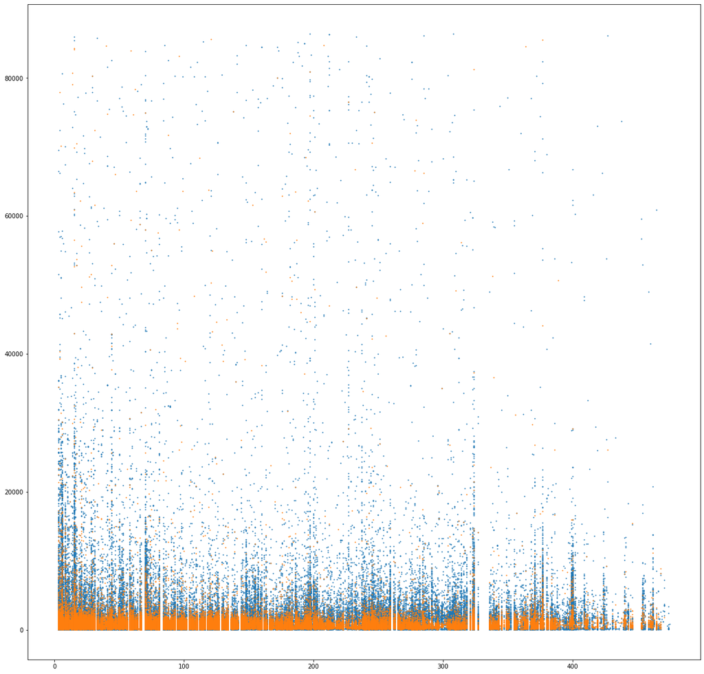

```python
df_roundtrips = df_rides.query('start_station_id == end_station_id')

rides_sample = np.random.choice(df_rides.shape[0],122230, replace = False);
rides_sample = df_rides.loc[rides_sample];

plt.figure(figsize=(20,20))

plt.scatter(data = df_roundtrips, x = 'start_station_id', y = 'duration_sec', alpha=1, s=1);
plt.scatter(data = rides_sample, x = 'start_station_id', y = 'duration_sec', alpha=1, s=1, color=secondary_color);

# plt.legend(['Round trip','Normal']);
```

## Start/End map

In this scatter plot dots are placed according to their coordinates, and their size represents the amount of transactions. Orange (end) is plotted over blue (start).

```
(37.7, 37.9)
```

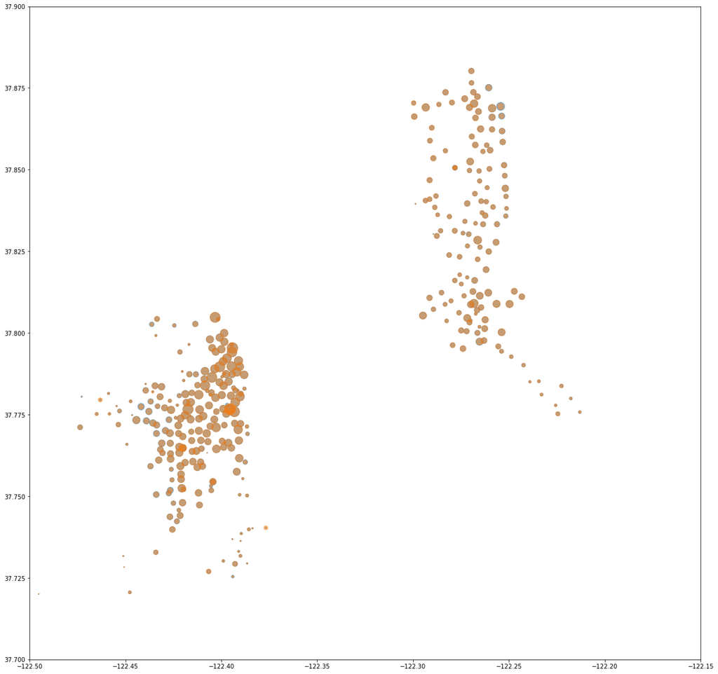

```python
# San Francisco and Berkeley
plt.figure(figsize=(20,20))
plt.scatter(data = df_stations_clean, x = 'longitude', y = 'latitude', s=df_stations_clean['starts']**0.5, alpha=0.5)
plt.scatter(data = df_stations_clean, x = 'longitude', y = 'latitude', s=df_stations_clean['ends']**0.5, color=secondary_color, alpha=0.5)
plt.xlim(-122.5,-122.15)
plt.ylim(37.7,37.9)
```